# Graphics in R: ggplot

## Add color

Perhaps we can get a better understanding of what is happening in Saanich Inlet if we instead plot all 3 variables of interest on 1 plot.

One way to achieve this is to map the third variable as a color aesthetic on a plot of the other 2 variables like so. *Note that the tidyverse understands both ‘color’ and ‘colour’.*

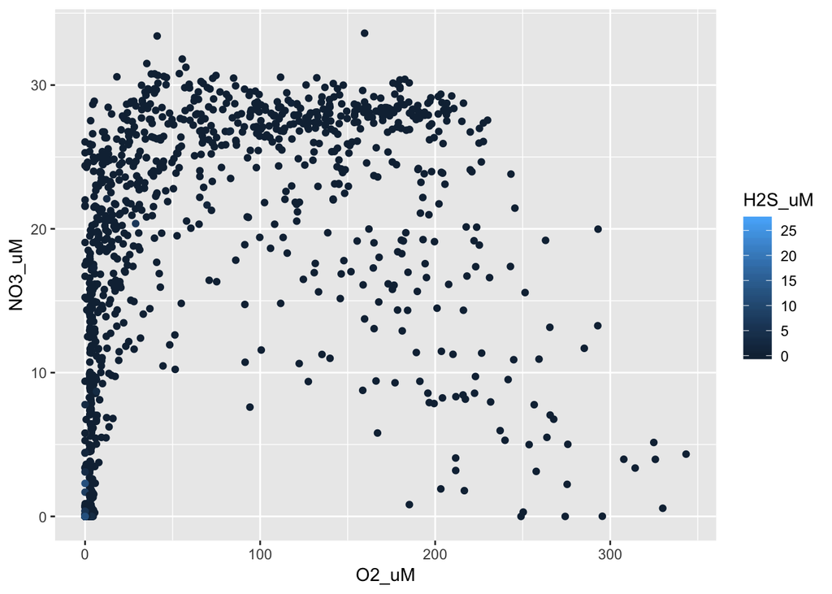

```r
dat %>%
  ggplot(aes(x=O2_uM, y=NO3_uM, color=H2S_uM)) +
  geom_point()
```

However, ggplot plots the observations in the order that they appear in the data frame. Since most of the hydrogen sulfide values are zero, we want to plot the non-zero data *last* so that they are visually on top in the plot. To do this, we use arrange by this variable to sort the rows by ascending hydrogen sulfide values. We also remove observations without hydrogen sulfide data (NA) since these will not map to any color.

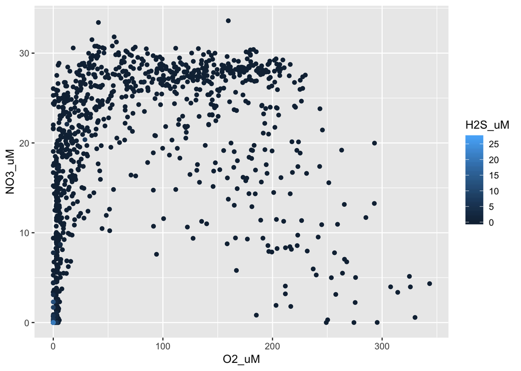

```r
dat %>%
  arrange(H2S_uM) %>%
  filter(!is.na(H2S_uM)) %>%

  ggplot(aes(x=O2_uM, y=NO3_uM, color=H2S_uM)) +
  geom_point()
```

This is a great example of why we use a pipe to input data into `ggplot`. Doing so allows us to manipulate `dat` using other tidyverse functions and then input these modified data directly into a ggplot without saving an intermediate data frame in the R environment.

## Add shape

We could also map a third variable to shape. However, this only works for categorical data so mapping to hydrogen sulfide fails.

```r
dat %>%
  arrange(H2S_uM) %>%
  filter(!is.na(H2S_uM)) %>%

  ggplot(aes(x=O2_uM, y=NO3_uM, shape=H2S_uM)) +
  geom_point()
```

```
## Error: A continuous variable can not be mapped to shape
```

So, we need to rethink how we are plotting these data if we want to use shape. One option is to instead plot all 3 variables as shapes along depth. We would do so with the following setup. But what are our x and shape variables?

```r
dat %>%
  ggplot(aes(x=?, y=Depth_m, shape=?)) +
  geom_point()
```

We actually have multiple variables that we want to input for x (oxygen, nitrate, hydrogen sulfide). So, what do we do?

This is where more tidyverse data manipulation can be used. Since we need a single variable to use as x, we need to `gather` our 3 geochemical variables into a single column. We also have to keep (but not gather) our future y-variable, *i.e.* Depth.

```r
dat %>%
  select(Depth_m, O2_uM, NO3_uM, H2S_uM) %>%
  gather(key="Chemical", value="Concentration", -Depth_m)
```

```
## # A tibble: 3,747 x 3
##    Depth_m Chemical Concentration
##      <dbl> <chr>            <dbl>
##  1      10 O2_uM            225.
##  2      20 O2_uM            221.
##  3      40 O2_uM            202.
##  4      60 O2_uM            198.
##  5      75 O2_uM            194.
##  6      85 O2_uM            150.
##  7      90 O2_uM            122.
##  8      97 O2_uM            108.
##  9     100 O2_uM             99.8
## 10     110 O2_uM             39.6
## # ... with 3,737 more rows
```

*Remember that the key (Chemical) and value (Concentration) names are determined by us! You could use different names.*

If we pipe these modified data into our plot, we now have individual variables to use as x and shape.

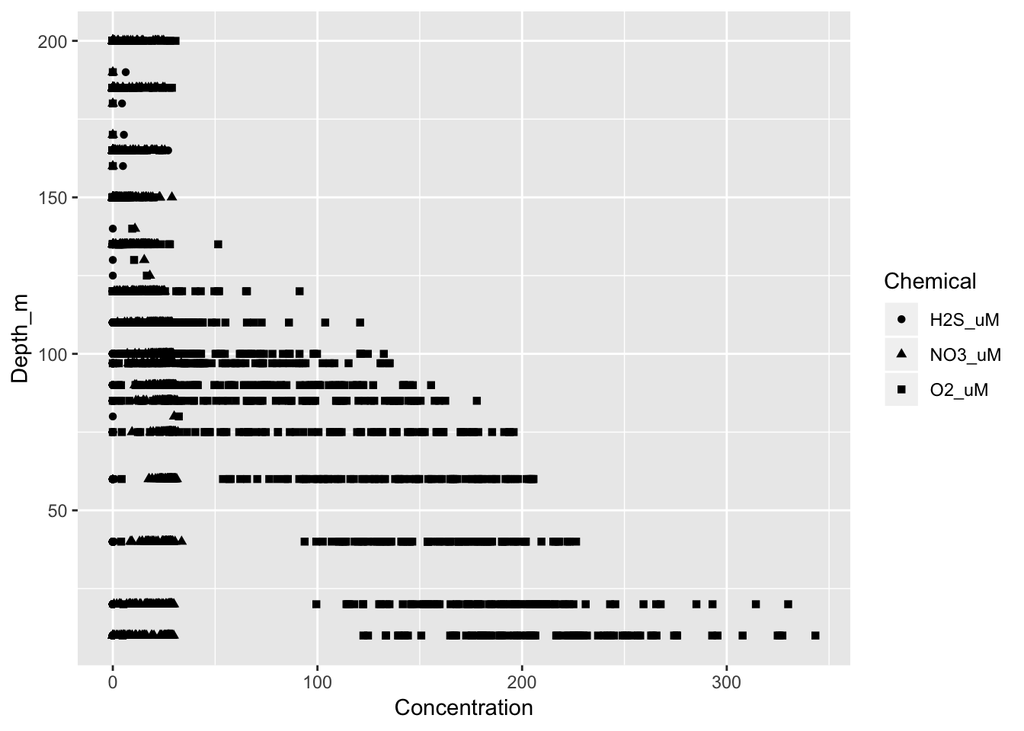

```r
dat %>%
  select(Depth_m, O2_uM, NO3_uM, H2S_uM) %>%
  gather(key="Chemical", value="Concentration", -Depth_m) %>%

  ggplot(aes(x=Concentration, y=Depth_m, shape=Chemical)) +
  geom_point()
```

We could further customize this plot by reversing the y-axis (since we traditionally think of depth going down) and adding color on top of shape!

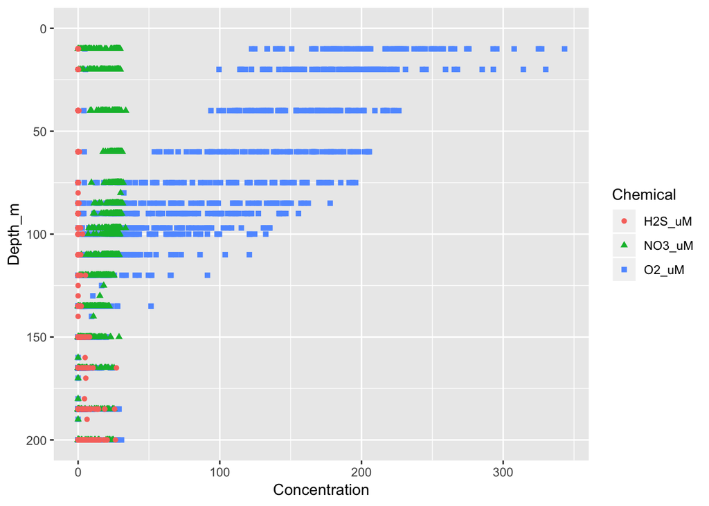

```r
dat %>%
  select(Depth_m, O2_uM, NO3_uM, H2S_uM) %>%
  gather(key="Chemical", value="Concentration", -Depth_m) %>%

  ggplot(aes(x=Concentration, y=Depth_m, shape=Chemical, color=Chemical)) +
  geom_point() +
  scale_y_reverse(limits=c(200, 0))
```

Now what do you think about our hypotheses?

### Exercise: color and shape

1. Create a plot of oxygen, nitrate, and hydrogen sulfide like above but only including Cruise 72.
2. Modify the x- and y-axes labels in this plot. *Hint* look at the R cheatsheet to find the guide functions to achieve this.

## Additional resources

- [R cheatsheets](https://www.rstudio.com/resources/cheatsheets/) also available in RStudio under Help > Cheatsheets
- [ggplot tutorial 1](http://r-statistics.co/Complete-Ggplot2-Tutorial-Part1-With-R-Code.html)
- [ggplot tutorial 2](https://rpubs.com/g_jw/ggplot2_tutorial)
- [ggplot tutorial 3](http://tutorials.iq.harvard.edu/R/Rgraphics/Rgraphics.html#the_1_faq)